# Walkthrough with kidney dataset

Suoqin Jin, Lihua Zhang

This walkthrough will perform integrative analysis of paired single cell RNA-seq and ATAC-seq data of mouse kidney cells, including 8837 co-assayed cells. The data is downloaded from GEO (GSM3271044 and GSM3271045) that were co-assayed using the sci-CAR protocol (Cao, J. et al. Joint profiling of chromatin accessibility and gene expression in thousands of single cells. Science 361, 1380-1385 (2018)).

Load the required libraries

```r
library(scAI)
library(dplyr)
library(cowplot)
```

## Load data

The algorithm takes a list of two digital data matrices as input. Genes/loci should be in rows and cells in columns. rownames and colnames should be included. Before running the scAI model, we need to normalize the data to account for library size and select highly variable features. Our preprocessed data matrices after qualify control, normalization and feature selection were provided for this walkthrough.

```r
load("/Users/suoqinjin/Documents/scAI-master/data/data_kidney.Rdata")
X <- data_kidney$data # List of data matrix
labels <- data_kidney$labels # the prior labels of cells
```

## Create a scAI object

```r
scAI_outs <- create_scAIobject(raw.data = X, do.sparse = F)
```

## Preprocess data

Perform quality control to remove low-quality cells and genes, and normalize the data. Since this is a preprocessed data, we set `assay = NULL`.

```r
scAI_outs <- preprocessing(scAI_outs, assay = NULL)
```

Add cell information into *pData* slot of the object

```r
scAI_outs <- addpData(scAI_outs, pdata = labels, pdata.name = "Cell types")
```

## Run scAI model

As depending on the random initilization the results might differ, one run scAI multiple times (e.g. nrun = 5) and output the best result. User can also output results from all runs by setting *keep_all = TRUE*. One parameter here is the number of components. The `selectK` function can aid in selecting K. A suitable K is the one at which the magnitude of cophenetic correlation begins to fall. Here, we only run one time.

```r
scAI_outs <- run_scAI(scAI_outs, K = 20, nrun = 1, do.fast = T)
fit <- scAI_outs@fit
save(fit, file = "results_scAI_fit.RData") # save the inferred low-dimensional representations
```

## Identify cell clusters

We can also identify cell clusters based on the inferred cell loading matrix using Leiden algorithm.

```r
scAI_outs <- identifyClusters(scAI_outs, resolution = 0.9)
scAI_outs <- getAggregatedData(scAI_outs, group = scAI_outs@identity)
```

## Visualize cells onto the low-dimensional space

We can visualize cells onto the low-dimensional space generated by t-SNE, FIt-sne or UMAP. Here, we perform UMAP dimension reduction. Cells are colored by the clustering inferred by scAI.

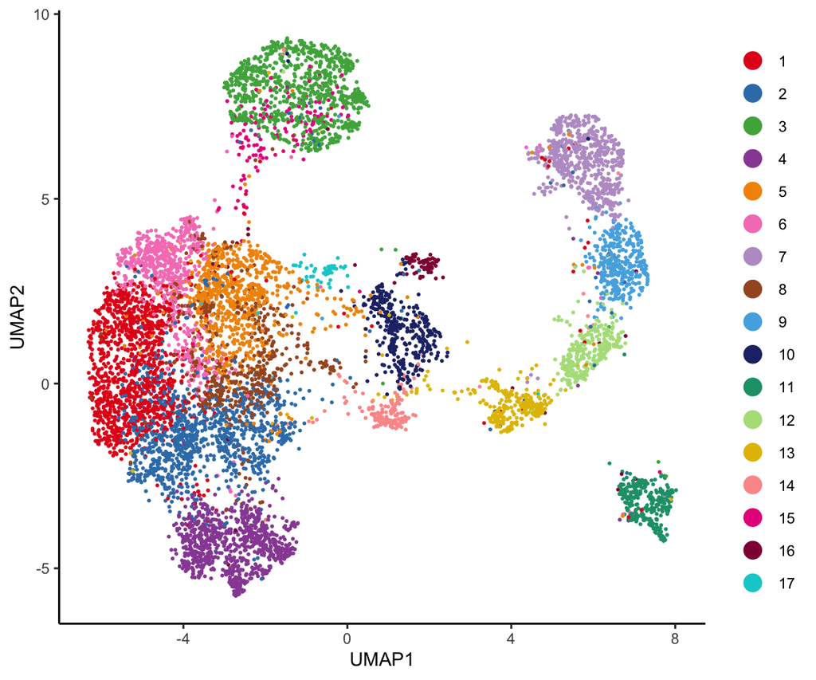

```r
scAI_outs <- reducedDims(scAI_outs, method = "umap")
cellVisualization(scAI_outs, scAI_outs@embed$umap, color.by = "cluster")
```

## Feature plot of the inferred patterns

We can overlay the expression of features, or the cell loading values onto the low-dimensional space, e.g., VscAI, tsne, umap

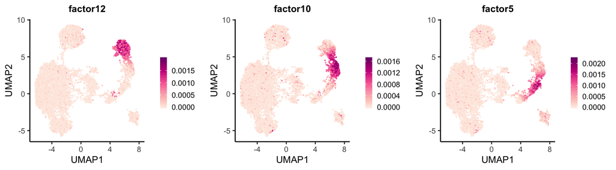

```r
featureScoreVisualization(scAI_outs, feature.scores = t(scAI_outs@fit$H), feature.use = paste0("factor",c(12,10,5)),  method = "umap", nCol = 3, cell.size = 0.1, show.legend = T, show.legend.combined = F)
```

### Ranking the features (genes/loci) and highlighting the important markers in each factor

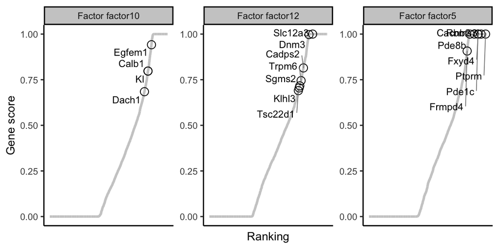

```r
feature_genes = c('Slc12a3','Trpm6','Klhl3','Wnk1','Tsc22d1','Cadps2',
                  'Egfem1','Calb1','Kl','Temem72','Dach1','Ptprm','Sgms2','Tox3','Frmpd4',
                  'Rbms3','Fxyd4','Dnm3','Cacnb2','Pde1c','Pde8b')

featureRankingPlot(scAI_outs,assay = 'RNA',  factor.show = c(12,10,5), ncol = 3, feature.show = feature_genes, top.p = 0.25, ylabel = "Gene score")
```

### Identify differentially expressed features of each cell cluster

```r
options(future.globals.maxSize = 10*1024 * 1024^2)
future::plan("multiprocess", workers = 4)
markers.ATAC.cluster <- identifyClusterMarkers(scAI_outs, assay = 'ATAC')
```

### Generate a heatmap to show the expression patterns of top features in cell clusters

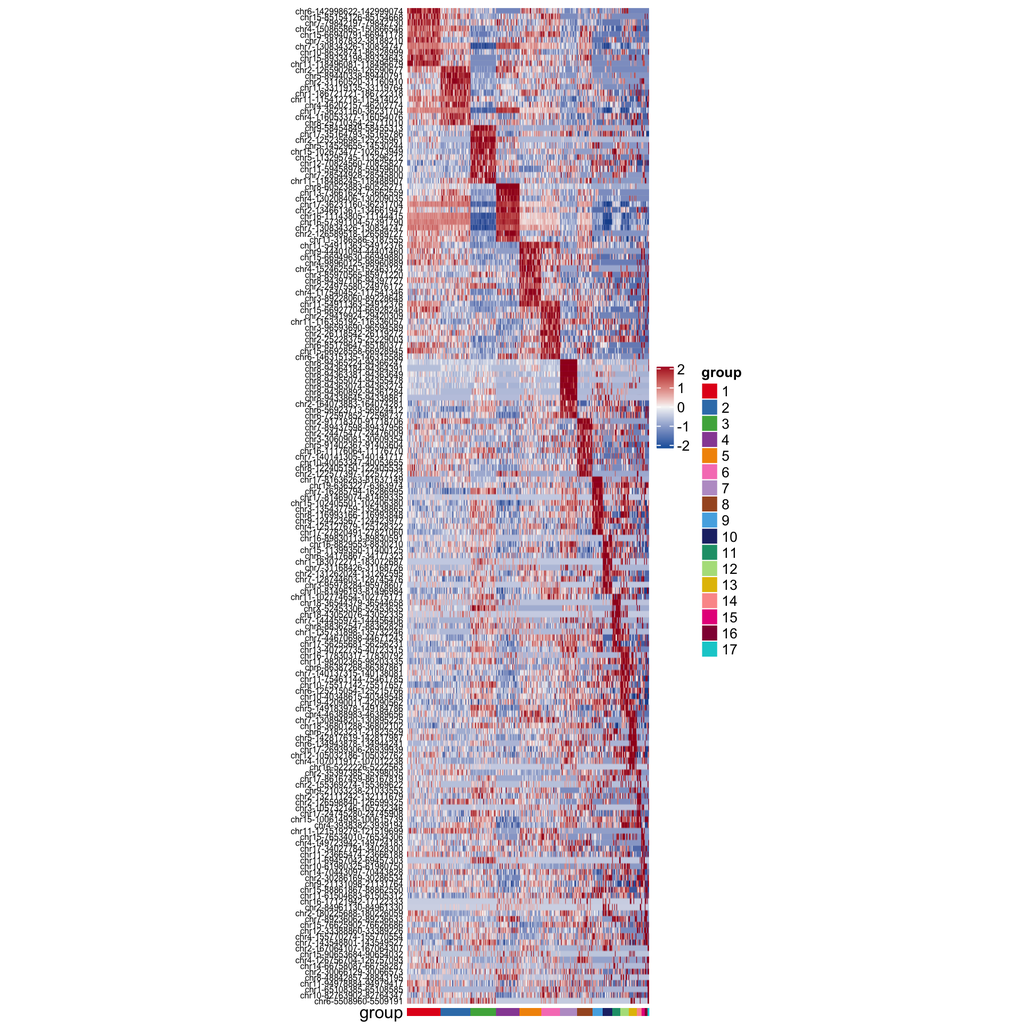

```r
n.top = 10
markers.ATAC.clusterTop <- markers.ATAC.cluster %>% group_by(clusters) %>% top_n(n.top, logFC) %>% slice(1:n.top)
featureHeatmap(scAI_outs, assay = "ATAC", feature.use = markers.ATAC.clusterTop$features, group.by = "cluster", size.names = 6)
```